# LSH para distancia euclideana

### Hashes para distancia euclideana

Para distancia euclideana, podemos usar los siguientes hashes, dado un ancho de cubeta $r$

1. Escogemos una dirección al azar $v$
2. El hash de un punto $x$ se calcula como sigue:
- Calculamos el tamaño de la proyección $x$ sobre $v$
- Dividimos este tamaño entre $r$
- el hash la parte entera de este último número

Es decir,
$$h(x) = \left\lfloor{ \frac{x\cdot v}{r}}\right\rfloor$$

Por ejemplo, si $v=(1,2)$, y $r = 1$:

```r
library(tidyverse)
norma <- function(x) sqrt(sum(x^2))
v <- c(1,2) / norma(c(1,2))
v
```

```
[1] 0.4472136 0.8944272
```

```r
hash_1 <- function(x) floor(sum(x * v) / 1)
hash_1(c(5,0))
```

```
[1] 2
```

```r
hash_1(c(0,-1))
```

```
[1] -1
```

```r
hash_1(c(2,1))
```

```
[1] 1
```

**Pregunta 1**: Haz un dibujo mostrando $v$, $v$ dividido en cubetas de ancho 1, y explica por qué los hashes de estos tres puntos dan este resultado.

Las direcciones las escogemos al azar, así que nuestra función generadora de hashes es:

```r
gen_hash <- function(d, r){
  # d es la dimensión y r es el ancho de las cubetas
  #
  # escogemos una dirección al azar
  v <- rnorm(d)
  v <- v / norma(v)
  # devolvemos una función que calcula la cubeta:
  function(x){
    floor(sum(x * v) / r) %>% as.integer
  }
}
set.seed(823)
hash_1 <- gen_hash(2, 1)
# los hashes de dos puntos:
hash_1(c(4, 7))
```

```
[1] -7
```

```r
hash_1(c(-4, 7))
```

```
[1] 0
```

```r
# el vector que escogimos es
environment(hash_1)$v
```

```
[1] -0.9142366 -0.4051807
```

**Pregunta 2**: Da un argumento de porqué la cubeta es un entero que puede ser arbitrariamente grande o arbitrariamente negativo.

**Pregunta 3**: Explica intuitivamente por qué esta familia de hashes es una familia sensible a la localidad (es decir, explica cómo es la probabiidad de que dos puntos cercanos caigan en la misma cubeta, y cómo es la probabilidad de que dos puntos lejanos caigan en la misma cubeta)

### Miniejemplo

La siguiente función genera dos clusters de puntos mezclados con puntos distribuidos normales con desviación estándar relativamente grande

```r
set.seed(1021)
#puntos cercanos a (3,3,..., 3):
simular_puntos <- function(d = 2, n = 200){
  mat_1 <- matrix(rnorm(10 * d, sd = 0.01) + 3, ncol = d)
  #puntos cercanos al origen:
  mat_2 <- matrix(rnorm(10 * d, sd = 0.01) - 3, ncol = d)
  # puntos distribuidos alrededor del origen:
  mat_3 <- matrix(rnorm(n * d, sd = 5), ncol = d)
  datos_tbl_vars <- rbind(mat_3, mat_1, mat_2)  %>%
    as_tibble %>%
    mutate(id_1 = row_number())
  datos_tbl_vars
}
# diez puntos en cluster 1, diez en cluster , y 100 sin cluster:
datos_tbl_vars <- simular_puntos(d = 2, n = 100)
```

```
`as_tibble.matrix()` requires a matrix with column names or a `.name_repair` argument. Using compatibility `.name_repair`.
```

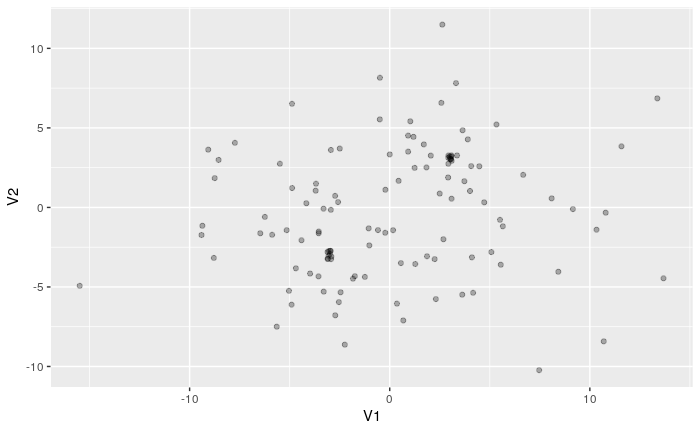

```r
ggplot(datos_tbl_vars, aes(x = V1, y= V2)) +
  geom_jitter(width = 0.1, height = 0.3, alpha = 0.3)
```

Para este ejemplo calculamos las distancias reales:

```r
dist_e <- function(x, y){
  norma(x - y)
}
datos_tbl <- datos_tbl_vars %>%
  pivot_longer(-id_1, names_to = "variable", values_to = "valor") %>%
  group_by(id_1) %>%
  arrange(variable) %>%
  summarise(vec_1 = list(valor))
system.time(
pares_tbl <- datos_tbl %>%
    crossing(datos_tbl %>%
        rename(id_2 = id_1, vec_2 = vec_1)) %>%
    filter(id_1 < id_2) %>%
    mutate(dist = map2_dbl(vec_1, vec_2, dist_e))
)
```

```
   user  system elapsed
  0.017   0.000   0.017
```

```r
pares_tbl %>% head
```

| id_1 | vec_1 | id_2 | vec_2 | dist |
| --- | --- | --- | --- | --- |
| 1 |  | 2 |  | 3.535502 |
| 1 |  | 3 |  | 12.104137 |
| 1 |  | 4 |  | 14.482426 |
| 1 |  | 5 |  | 12.433539 |
| 1 |  | 6 |  | 1.653051 |
| 1 |  | 7 |  | 8.115561 |

```r
nrow(pares_tbl)
```

```
[1] 7140
```

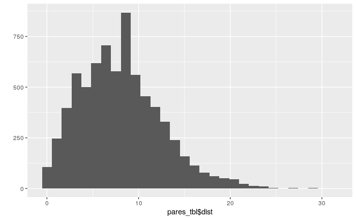

```r
qplot(pares_tbl$dist)
```

Supongamos que queremos encontrar los puntos que están a distancia menor a 0.5

```r
pares_sim <- pares_tbl %>% filter(dist < 0.5)
nrow(pares_sim)
```

```
[1] 103
```

Para estos datos chicos podemos visualizar los pares similares como sigue:

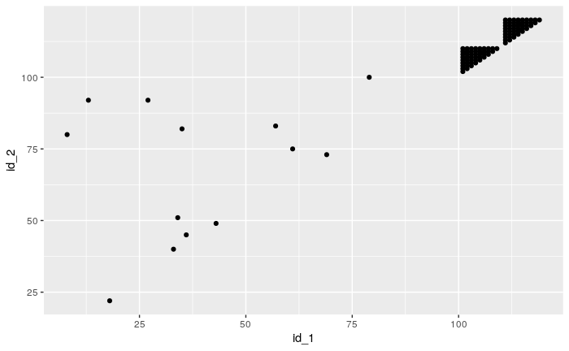

```r
ggplot(pares_sim, aes(x=id_1, y=id_2)) + geom_point()
```

**Pregunta 4**: Explica por qué en este ejemplo particular debemos encontrar un poco más de 90 pares. ¿Cuál es el total de pares en estos datos? ¿Qué significan los patrones en la última gráfica?

### Cálculo de firmas

Usaremos 3 hashes con tamaño de cubeta = 0.2:

```r
#generar hashes
hash_f <- map(1:3, ~ gen_hash(d = 2,  r = 0.2))
# esta es una función de conveniencia:
calculador_hashes <- function(hash_f){
  function(z) {
    map_int(hash_f, ~ .x(z))
  }
}
calc_hashes <- calculador_hashes(hash_f)
```

Calculamos las firmas:

```r
firmas_tbl <- datos_tbl_vars %>%
  pivot_longer(cols = -id_1, names_to = "variable", values_to = "valor") %>%
  group_by(id_1) %>%
  summarise(vec_1 = list(valor)) %>%
  mutate(firma = map(vec_1, ~ calc_hashes(.x))) %>%
  select(id_1, firma)
firmas_tbl
```

| id_1 | firma |
| --- | --- |
| 1 |  |
| 2 |  |
| 3 |  |
| 4 |  |
| 5 |  |
| 6 |  |
| 7 |  |
| 8 |  |
| 9 |  |
| 10 |  |

[output cut: 110 more lines]

```r
firmas_tbl$firma[[1]]
```

```
[1] -44   7   7
```

```r
firmas_tbl$firma[[2]]
```

```
[1] -46  24  24
```

### Cálculo de cubetas

Para este ejemplo, consideraremos todos los pares que coinciden en al menos una cubeta (hacemos disyunción de los 3 hashes):

```r
cubetas_tbl  <- firmas_tbl %>%
  unnest_legacy() %>%
  group_by(id_1) %>%
  mutate(hash_no = 1:3) %>%
  mutate(cubeta = paste(hash_no, firma, sep = "/"))
```

Ahora agrupamos cubetas y filtramos las que tienen más de un elemento

```r
cubetas_tbl <- cubetas_tbl %>% group_by(cubeta) %>%
  summarise(ids = list(id_1), n = length(id_1)) %>%
  filter(n > 1)
cubetas_tbl
```

| cubeta | ids | n |
| --- | --- | --- |
| 1/-1 |  | 2 |
| 1/-14 |  | 3 |
| 1/-16 |  | 3 |
| 1/-18 |  | 2 |
| 1/-21 |  | 12 |
| 1/-22 |  | 2 |
| 1/-24 |  | 2 |
| 1/-27 |  | 2 |
| 1/-28 |  | 3 |
| 1/-3 |  | 2 |

[output cut: 67 more lines]

Y finalmente, extraemos los pares candidatos:

```r
pares_candidatos <- map(cubetas_tbl$ids, function(x){
  combn(sort(x), 2, simplify = FALSE)}) %>%
  flatten %>% unique %>%
  transpose %>% map(as.integer) %>% as_tibble(.name_repair = "unique")
```

```
* `` -> ...1
* `` -> ...2
```

```r
names(pares_candidatos) <- c('id_1','id_2')
head(pares_candidatos)
```

| id_1 | id_2 |
| --- | --- |
| 25 | 34 |
| 59 | 65 |
| 59 | 98 |
| 65 | 98 |
| 22 | 23 |
| 22 | 56 |

```r
nrow(pares_candidatos)
```

```
[1] 269
```

Considera los pares recuperados, por ejemplo haciendo esta gráfica:

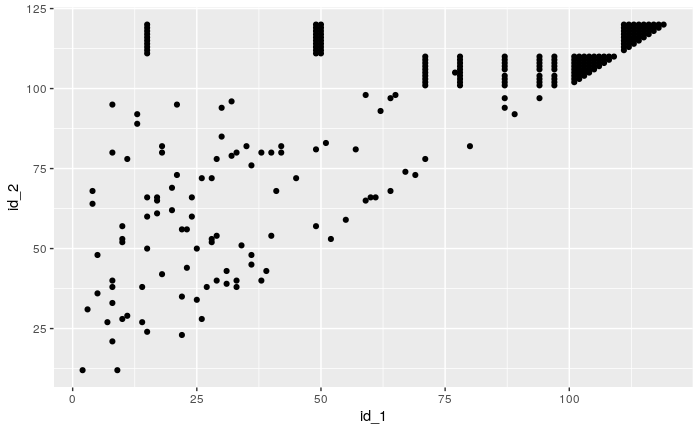

```r
ggplot(pares_candidatos, aes(x=id_1, y=id_2)) + geom_point()
```

**Pregunta 5**: según esta gráfica, ¿recuperaste con este método los pares que ocurren dentro de cada uno de los clusters? ¿Por qué?

**Pregunta 6**: Explica por qué no necesariamente todos los pares que encontraste tienen distancia menor a 0.5. ¿Cómo cambiarías el número de hashes para tener menos falsos positivos? y/o ¿Qué harías ahora para descartar esos pares?

**Pregunta 7**: Repite el ejercicio usando un ancho de cubeta de 3, y un ancho de cubeta de 0.01. ¿Cómo cambia el número de pares candidatos? ¿Qué crees que pase con el número de falsos positivos y falsos negativos?

**Pregunta 8**: Esta familia es $(r/2, 2r, 1/2, 1/3)$ sensible a la localidad. Si $r=0.25$ entonces es $(0.13, 0.5, 1/2, 1/3)$. Si la distancia entre dos puntos es menor a 0.13, ¿cuál es la probabilidad de que al menos un hash de los tres coincida? ¿Cómo es la probabilidad de que al menos un hash coincida cuando la distancia es mayor a 0.5?

**Pregunta 8** (opcional) Investiga cómo hacer esto usando spark (necesitas usar la función *ft_bucketed_random_projection_lsh*, y ve el código de minhashing de texto en spark)